# Analyse single-cell

```r
## Import des packages
library(Seurat)
library(ggraph)
library(ggplot2)
library(gridExtra)
library(RColorBrewer)
library(biomaRt)
require(plyr)
require(dplyr)
require(magrittr)
library(clustree)
```

# Analyse single cell via Seurat

Une analyse single-cell RNA seq classique consiste a identifier des populations de cellules ainsi que les genes marqueurs associes. Elle peut egalement rechercher l’effet d’un traitement ou d’une condition grace aux methodes d’analyse differentielle.

## Import des fichiers

### Matrice d’expression

Il faut importer en premier les donnees. Elles sont generalement sous la forme de 3 fichiers :

- le nom des transcriptomes `barcodes.tsv` : fichier a une colonne avec le nom des transcriptomes (cellules, barcodes)
- le nom des genes en format `genes.tsv` : fichier de trois colonnes (geneID de l’annotation gtf utilise, gene name, “Gene Expression”)
- la matrice d’expression `matrix.mtx` : fichier de trois colonnes position du transcriptome dans le fichier `barcodes.tsv`, position du gene dans le fichier `genes.tsv`, niveau d’expression associe)

La fonction `Read10X` de Seurat permet de creer a partir de ces fichiers la matrice d’expression en format `dgCMatrix`. C’est une sparse matrix utilisee pour un traitement efficace des grandes matrices.

```r
### Import expression matrix
system("wget https://cf.10xgenomics.com/samples/cell/pbmc3k/pbmc3k_filtered_gene_bc_matrices.tar.gz")
system("tar -zxvf pbmc3k_filtered_gene_bc_matrices.tar.gz")
tenX_matrix <- Read10X(data.dir = "./filtered_gene_bc_matrices/hg19", #path to the directory containing the three 10X files (matrix.mtx, genes.tsv (or features.tsv depending on the CellRanger version), barcodes.tsv)
                       gene.column = 1) #choice of the genes.tsv column that will determine the names of the genes in the expression matrix

##matrix dimension : first value is the number of row (genes) and second value is the number of column (sample/barcodes)
dim(tenX_matrix)
```

[1] 32738 2700

Il est preferable d’utiliser la colonne composee uniquement de gene ID lors de l’analyse (colonne 1) et de n’utiliser les gene names que lors de l’etape de l’annotation des genes marqueurs. En effet la colonne 2 de `genes.tsv` est en fait composee de gene name et de gene ID. Sachant surtout que plusieurs gene ID peuvent correspondre a un seul gene name, cela complexifie enormement l’etape d’annotation.  
Si on choisit la colonne 2, les duplicats dans les genes names sont gerees avec la fonction `make.unique` qui detecte les duplicats puis rajoute des `.1, .2, ..., .n` apres chaque occurence. La premiere occurence n’est pas modifiee.

Ici on utilise les datasets tests de Seurat que l’on peut retrouver sur le [tutoriel de Seurat](https://satijalab.org/seurat/articles/pbmc3k_tutorial.html).

Si le format de la matrice d’expression n’est pas en format trois fichiers mais un fichier contenant une table (*n* genes x *n* barcodes), on peut passer directement a l’etape suivante.

### Annotation biomaRt

On va ensuite importer la base de donnees biomart qui nous servira ensuite a annoter les genes de notre analyse. Cela permettra notamment de passer d’un Ensembl gene ID a un gene name. Les donnees de Seurat etant en hg19 on recupere la base de donnees pour cette annotation la.

```r
# Import of the biomart database for hg19
ensembl_hg19 <- useEnsembl(biomart = "genes",                  #import ensembl genes database
                           dataset = "hsapiens_gene_ensembl",  #genome
                           GRCh = 37)                          #genome version, only 38 or 37 are accepted for now

# Recovering attributes according to our gene list (genes present in our expression matrix)
annotated_hg19 <- getBM(attributes = c("ensembl_gene_id",
                                       "external_gene_name",
                                       "description",
                                       "gene_biotype",
                                       "chromosome_name"),    #informations to retrieve
                           filters = "ensembl_gene_id",       #which variable to choose for the filtering
                           values = rownames(tenX_matrix),    #values that will filter the database
                           mart = ensembl_hg19)               #database

#preview of the resulting dataframe
knitr::kable(head(annotated_hg19), "simple")
```

[output not shown]

## Creation de l’objet Seurat

Ensuite grace a la fonction `CreateSeuratObject` on va pouvoir importer cette matrice dans un objet Seurat qui va être la base de notre analyse. Toutes les differentes etapes vont être associees a cet objet qui est un objet S4 (arborescence d’autres objets plus petits, dataframe, vecteurs…), specifique a Seurat appele un `SeuratObject`.

```r
### Creation of the Seurat Object
pbmc_small <- CreateSeuratObject(tenX_matrix,                    #expression matrix
                                 project = "Seurat data test",   #name of the project
                                 assay = "RNA",                  #name of the initial assay, (others can be created during the analysis), default is RNA
                                 names.field = 1,                #associated with the names.delim, it allows to separate the name of the barcode when this one is composed of several information ex: BARCODE_CLUSTER_CELLTYPE and to choose after split on the names.delim which part we choose as the barcode name
                                 names.delim = "_",              #character that allows to dissociate the different information contained in the barcode names
                                 meta.data = NULL,               #we can add the metadata on the transcriptomes with a dataframe where the barcodes are in line and the different information in column
                                 min.cells = 0,                  #filtering genes that are not detected in less than min.cells
                                 min.features = 1)               #filtering cells that do not detect at least min.features, here we filter all barcodes that detect no gene

pbmc_small # Small presentation of the Seurat object in R console
```

```
## An object of class Seurat
## 32738 features across 2700 samples within 1 assay
## Active assay: RNA (32738 features, 0 variable features)
```

```r
# Discovery of SeuratObject
str(pbmc_small)
```

```
## Formal class 'Seurat' [package "SeuratObject"] with 13 slots
##   ..@ assays      :List of 1
##   .. ..$ RNA:Formal class 'Assay' [package "SeuratObject"] with 8 slots
##   .. .. .. ..@ counts       :Formal class 'dgCMatrix' [package "Matrix"] with 6 slots
##   .. .. .. .. .. ..@ i       : int [1:2286884] 70 166 178 326 363 410 412 492 494 495 ...
##   .. .. .. .. .. ..@ p       : int [1:2701] 0 781 2133 3264 4224 4746 5528 6311 7101 7634 ...
##   .. .. .. .. .. ..@ Dim     : int [1:2] 32738 2700
##   .. .. .. .. .. ..@ Dimnames:List of 2
##   .. .. .. .. .. .. ..$ : chr [1:32738] "ENSG00000243485" "ENSG00000237613" "ENSG00000186092" "ENSG00000238009" ...
##   .. .. .. .. .. .. ..$ : chr [1:2700] "AAACATACAACCAC-1" "AAACATTGAGCTAC-1" "AAACATTGATCAGC-1" "AAACCGTGCTTCCG-1" ...
##   .. .. .. .. .. ..@ x       : num [1:2286884] 1 1 2 1 1 1 1 41 1 1 ...
##   .. .. .. .. .. ..@ factors : list()
##   .. .. .. ..@ data         :Formal class 'dgCMatrix' [package "Matrix"] with 6 slots
##   .. .. .. .. .. ..@ i       : int [1:2286884] 70 166 178 326 363 410 412 492 494 495 ...
##   .. .. .. .. .. ..@ p       : int [1:2701] 0 781 2133 3264 4224 4746 5528 6311 7101 7634 ...
##   .. .. .. .. .. ..@ Dim     : int [1:2] 32738 2700
##   .. .. .. .. .. ..@ Dimnames:List of 2
##   .. .. .. .. .. .. ..$ : chr [1:32738] "ENSG00000243485" "ENSG00000237613" "ENSG00000186092" "ENSG00000238009" ...
##   .. .. .. .. .. .. ..$ : chr [1:2700] "AAACATACAACCAC-1" "AAACATTGAGCTAC-1" "AAACATTGATCAGC-1" "AAACCGTGCTTCCG-1" ...
##   .. .. .. .. .. ..@ x       : num [1:2286884] 1 1 2 1 1 1 1 41 1 1 ...
##   .. .. .. .. .. ..@ factors : list()
##   .. .. .. ..@ scale.data   : num[0 , 0 ]
##   .. .. .. ..@ key          : chr "rna_"
##   .. .. .. ..@ assay.orig   : NULL
##   .. .. .. ..@ var.features : logi(0)
##   .. .. .. ..@ meta.features:'data.frame':   32738 obs. of  0 variables
##   .. .. .. ..@ misc         : list()
##   ..@ meta.data   :'data.frame': 2700 obs. of  3 variables:
##   .. ..$ orig.ident  : Factor w/ 1 level "Seurat data test": 1 1 1 1 1 1 1 1 1 1 ...
##   .. ..$ nCount_RNA  : num [1:2700] 2421 4903 3149 2639 981 ...
##   .. ..$ nFeature_RNA: int [1:2700] 781 1352 1131 960 522 782 783 790 533 550 ...
##   ..@ active.assay: chr "RNA"
##   ..@ active.ident: Factor w/ 1 level "Seurat data test": 1 1 1 1 1 1 1 1 1 1 ...
##   .. ..- attr(*, "names")= chr [1:2700] "AAACATACAACCAC-1" "AAACATTGAGCTAC-1" "AAACATTGATCAGC-1" "AAACCGTGCTTCCG-1" ...
##   ..@ graphs      : list()
##   ..@ neighbors   : list()
##   ..@ reductions  : list()
##   ..@ images      : list()
##   ..@ project.name: chr "Seurat data test"
##   ..@ misc        : list()
##   ..@ version     :Classes 'package_version', 'numeric_version'  hidden list of 1
##   .. ..$ : int [1:3] 4 0 2
##   ..@ commands    : list()
##   ..@ tools       : list()
```

```r
dim(pbmc_small@assays$RNA@counts)
```

```
## [1] 32738  2700
```

```r
dim(pbmc_small@assays$RNA@data)
```

```
## [1] 32738  2700
```

```r
knitr::kable(head(pbmc_small@meta.data), "simple") # preview of the cell metadata
```

|  | orig.ident | nCount_RNA | nFeature_RNA |
| --- | --- | --- | --- |
| AAACATACAACCAC-1 | Seurat data test | 2421 | 781 |
| AAACATTGAGCTAC-1 | Seurat data test | 4903 | 1352 |
| AAACATTGATCAGC-1 | Seurat data test | 3149 | 1131 |
| AAACCGTGCTTCCG-1 | Seurat data test | 2639 | 960 |
| AAACCGTGTATGCG-1 | Seurat data test | 981 | 522 |
| AAACGCACTGGTAC-1 | Seurat data test | 2164 | 782 |

Ici on peut donc voir apparaitre plusieurs slots differents :

- assays : slot general qui comprendra les differentes informations de chaque etude. Elles sont composees de plusieurs choses :
  - la matrice d’expression de depart (`@counts`), habituellement des raw counts ou raw UMI
  - celle qui va “subir” toutes les modifications (filtres, normalisation, etc) (`@data`)
  - dataframe qui sera cree lors du scaling des data (`@scale_data`)
  - prefixe utilise pour chaque calcul qui utilisera cet assay (etude) (`@key`)
  - vecteur des noms de genes qui seront determines comme ayant une expression variable (`@var.features`)
  - dataframe associe aux genes avec les differentes metadata (`@meta.features`)
- meta.data : regroupe toutes les informations concernant les cellules. Au depart Seurat va calculer la taille de la librarie (nCount_RNA, ou le nombre d’UMI) et le nombre de genes detectes (nFeatures_RNA) pour chaque cellule. Si on lui renseigne un dataframe dans le parametre `meta.data` de la fonction `CreateSeuratObject`, ses colonnes seront ajoutees apres celles calculees par Seurat.
- active.assay : etude utilise par defaut
- active.ident : identite des cellules par defaut, ici le nom du projet donne, stocke aussi sous la colonne `orig.ident` dans les metadata

La navigation dans les differents slots se fait via `@` ou `$`. Chaque slot principal est accessible via le `@`, c’est a dire `nomobjet@slotprincipal` pour aller plus loin dans l’arborescence des slots, le plus souvent les objets complexes sont accessibles avec un `@` (dgCMatrix, dataframe) et les listes, vecteurs sont accessibles via `$`. Au moindre doute, on peut se referer au resultat de la commande `str`.

## Pre-processing

Les etapes du preprocessing servent a nettoyer les donnees afin de ne pas fausser les resultats des analyses en aval (analyse du regroupement des cellules, des marqueurs, analyses differentielles d’expression).

### Filtrage des cellules de faible qualite

La premiere etape est de filtrer les cellules qui sont de pauvre qualite. Cela peut concerner les cellules qui ont explose lors la prepation de la librarie, les *beads* vides ou qui contiennent de l’ARN ambiant, etc… On va pouvoir se baser sur differents parametres comme le nombre de genes detectes, le nombre d’UMI, le pourcentage de genes de la mitochondrie exprimes…

#### Calcul du pourcentage de genes mitochondriaux

Un haut taux d’expression des genes du genome MT peut exprimer une cellule en apoptose.

Grâce a la fonction `PercentageFeatureSet`, on calcule pour chaque cellule du % d’expression des genes mitochondriaux parmi tous les genes exprimes. Si on utilise les gene names, on peut directement utilise le parametre `pattern` en renseignant “*^MT-*” pour capturer tous les genes commencant par “*MT-*”. S’il n’y a pas de pattern dans les noms de genes, grâce au parametre `features` on lui renseigne directement un vecteur contenant les genes presents sur le genome MT. On peut s’aider de l’annotation Biomart en recuperant tous les genes present sur le chromosome MT si les ID (ou les gene names) n’ont pas de prefixe pour les differencier. La fonction `PercentageFeatureSet` ajoute une colonne avec les valeurs de % dans les metadata des cellules (`nomobjet@meta.data`).

On considere generalement une cellule en apoptose lorsque le transcriptome detecte plus de 20% les genes du genome MT. Certains sont plus stringeant en abaissant ce seuil a 10%.

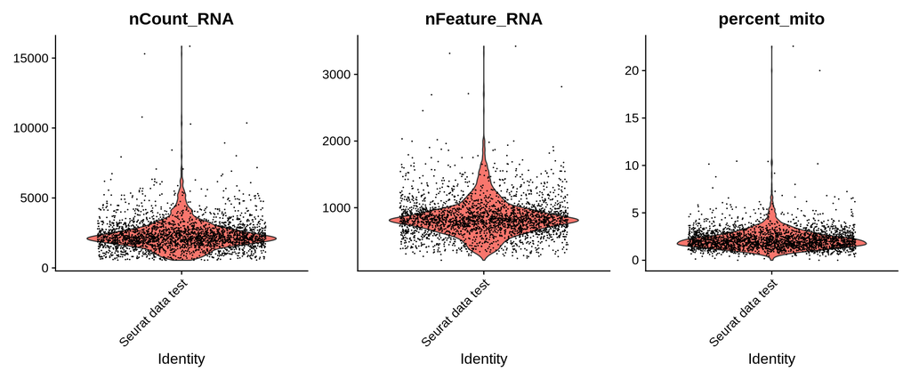

```r
##Retrieve genes from the MT genome using biomart
genes_MT <- annotated_hg19$ensembl_gene_id[annotated_hg19$chromosome_name == "MT"]


pbmc_small <- PercentageFeatureSet(pbmc_small,
                                   features = genes_MT,        # vectors of gene names present on the MT genome
                                   col.name = "percent_mito",  # Defines the name of the new column generated in the metadata of the Seurat object
                                   assay = "RNA")

###Violin plot of QC (Quality Controls)
VlnPlot(object = pbmc_small,
        features = c("nCount_RNA", "nFeature_RNA", "percent_mito"), # Parameters to plot (either gene expression or continuous variable in cell metadata)
        ncol = 3,                                                   # Number of columns if several figures are to be ploted
        pt.size = 0.01)                                             # Point size
```

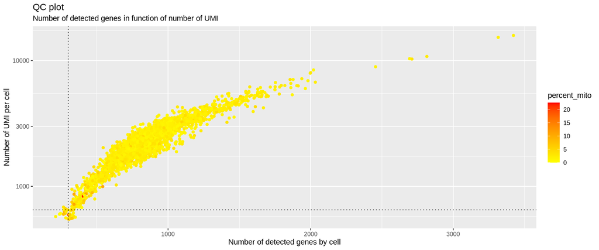

```r
###Graphical representation of QC

ggplot(pbmc_small@meta.data,
       aes(y = nCount_RNA,
           x = nFeature_RNA,
           color = percent_mito)) +
  geom_point() +
  geom_hline(yintercept = 650, linetype = 'dotted') +
  geom_vline(xintercept = 300, linetype = 'dotted') +
  scale_y_log10() +
  scale_color_gradient2(low = "green",
                        high = "red",
                        mid = "yellow") +
  ggtitle("QC plot", "Number of detected genes in function of number of UMI")+
  labs(y = "Number of UMI per cell", x = "Number of detected genes by cell")
```

Grâce a ces plots de controles qualites on va pouvoir essayer de differencier les cellules de bonnes qualites des autres. Pour ce faire, on regarde les differentes distributions et on essaye d’identifier deux populations on etabli le seuil comme etant la valeur qui va les separer. Sachant que les cellules de pauvre qualite sont celles qui vont exprimer peu de genes, faiblement et/ou exprimer fortement les genes du genome MT.

#### Seuils des differents filtres

On peut donc identifier les cellules outliers. Dans le dernier plot, on voit un nuage de point qui se decroche du reste des cellules. Sur le dernier violin plot pour la distribution du `percent_mito` on peut choisir le seuil a 10% car les outliers se trouvent plutot au dessus de 10%.

Pour filtrer un objet Seurat on utilise simplement la fonction `subset` ou on filtre selon les valeurs contenues dans le dataframe des metadata.

On va retirer toutes les cellules :

- dont la taille de la librarie est inferieur a 650 UMI
- qui detectent moins de 300 genes
- dont le pourcentage de genes du genome MT exprimes depasse 10%.

> Attention le `&` dans la commande subset correspond a un `OU` et non un `ET`. Le pipe (`|`) ne fonctionne pas quand on utilise subset avec un objet seurat

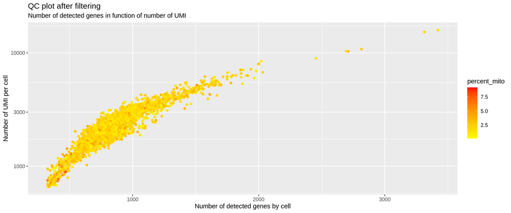

```r
#filtering SeuratObject
pbmc_small <- subset(pbmc_small,
                     percent_mito < 10 &
                       nCount_RNA > 650 &
                       nFeature_RNA > 300)

#plot
ggplot(pbmc_small@meta.data,
               aes(y = nCount_RNA,
                   x = nFeature_RNA,
                   color = percent_mito)) +
  geom_point() +
  scale_y_log10() +
  scale_color_gradient2(low = "green",
                        high = "red",
                        mid = "yellow") +
  ggtitle("QC plot after filtering", "Number of detected genes in function of number of UMI")+
  labs(y = "Number of UMI per cell", x = "Number of detected genes by cell")
```

```r
#update object in R console
pbmc_small
```

An object of class Seurat 32738 features across 2665 samples within 1 assay Active assay: RNA (32738 features, 0 variable features)

### Normalisation des donnees

La normalisation des donnees permet de s’affranchir des biais specifiques aux cellules (ex : sequencing depth, amplification, GC content). Elle permet de rendre comparable les libraries. Pour cela on va utiliser la fonction de Seurat, `NormalizeData` qui se base sur l’hypothese que chaque cellule contient la même quantite d’ARN. Avec la methode `logNormalize`, chaque UMI est normalise comme suit, pour chaque cellule :

> norm_UMI = log2(UMI / nCount_RNA) * scale_factor +1)

Le `scale_factor` est defini par defaut a 10 000, le plus souvent on utilise la mediane de la taille des libraries (= nombre total d’UMI par cellule, = nCount_RNA dans les meta.data). Si le scale factor est egal a 1e6 alors on obtiendrait des log2(CPM+1). *CPM : Count Per Million*

```r
#inter-cell normalization
pbmc_small <- NormalizeData(pbmc_small,                                   #SeuratObject
                            assay = "RNA",                                #assay to use
                            normalization.method = "LogNormalize",        #normalization method
                            scale.factor = median(pbmc_small$nCount_RNA), #scale factor
                            verbose = TRUE)
```

Le slot `@data` sera mis a jour avec les UMI normalises.

> Tips : il existe un raccourci pour acceder aux colonnes des metadata : `nomobjet@meta.data$column == nomobjet$column`

### Identification des genes les plus variables

On peut representer chaque cellule comme la combinatoire de l’expression de chaque gene. Il y a donc enormement de dimensions ce qui engendre beaucoup de bruit de fond.

Une premiere etape est de retirer les genes qui contiennent tres peu d’information, c’est a dire les genes qui sont peu/pas exprimes ou ceux qui sont exprimes de facon equivalente pour toutes les cellules. Ces genes la ne pourront pas aider a differentier les cellules entre elles. En les retirant, on permettra l’amelioration des methodes de reduction de dimension et de clustering pour une inference statistique fiable (ou en tout cas en enlevant du bruit de fond).

Pour identifier les genes les plus variables on utilise la fonction de Seurat `FindVariableFeatures` avec la methode `vst` qui se base sur la relation entre la moyenne d’expression et la variance de chaque gene. Avec le parametre `nfeatures` on recupere les 2000 genes les plus variables selon la methode vst.

```r
pbmc_small <- FindVariableFeatures(pbmc_small,                 #SeuratObject
                                   selection.method = "vst",   #method
                                   nfeatures = 2000)           #top HVG (Highly Variable Gene), default value
pbmc_small
```

An object of class Seurat 32738 features across 2665 samples within 1 assay Active assay: RNA (32738 features, 2000 variable features)

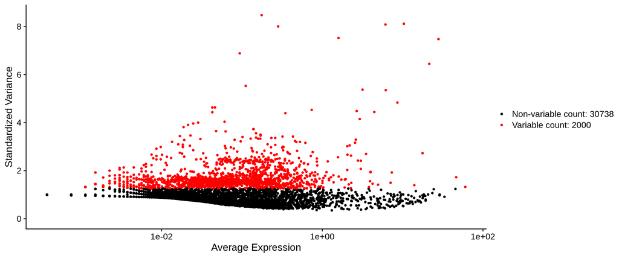

```r
#plot
VariableFeaturePlot(pbmc_small)
```

La fonction `FindVariableFeatures` mets a jour deux slots :

- `pbmc_small@assays$RNA@var.features` : vecteur des n genes determines comme etant les plus variables
- `pbmc_small@assays$RNA@meta.features` : dataframe contenant les diffentes variables calculees lors de la methode vst. Pour chaque gene on a :
  - `vst.mean` : moyenne d’expression
  - `vst.variance` : variance d’expression
  - `vst.variance.expected` : variance attendue
  - `vst.variance.standardized` : variance standardisee
  - `vst.variable` : logique, est-ce que le gene est un gene variable TRUE / FALSE

> Tips : On peut acceder directement au vecteur des genes les plus variables grace a : `VariableFeatures(pbmc_small)`

## Reduction des dimensions

Afin d’identifier les groupes de cellules, il faut reduire encore l’espace dimensionnel dans lequel les cellules evoluent. Il existe differentes methodes de reduction de dimension qui vont nous aider a atteindre notre objectif : visualiser et identifier les populations de cellules dans un espace dimensionnel faible et pertinent. Ici nous allons voir deux methodes, la premiere est l’analyse en composantes principales (appelee apres PCA) et la seconde qui se base sur la premiere : l’Approximation et Projection d’un Manifold Uniforme (UMAP).

### Scaling des data

La premiere etape est de realiser un scaling des data. Cette etape est obligatoire pour pouvoir inferer une PCA. La fonction Seurat `ScaleData` centre et reduit les donnees en ne prenant que les HVG par defaut. Il est possible aussi de lui fournir un vecteur de variables a regresser (le plus souvent on lui donne les noms de colonnes dans le slot `meta.data` associes).

```r
pbmc_small <- ScaleData(pbmc_small)
```

Le slot `nomobjet@assays$RNA@scale.data` est maintenant renseigne. C’est un dataframe de dimensions `n HVG x n cellules` des donnees centrees reduites.

### Analyses en composantes Principales (ACP)

Un espace a 2000 dimensions est toujours trop important pour trouver facilement les similarites et differences entre cellules. On va maintenant utiliser une methode de reduction de dimension appele PCA. Sommairement, la PCA va representer le nuage de point dans les 2000 dimensions puis chercher l’angle qui permettra d’eclater au maximum les cellules sur un plan. Les dimensions resultantes sont appelees composantes principales (PCs) et sont composees d’une combinatoire des precedentes dimensions (les expression de genes).

Pour cela, nous allons utiliser la fonction Seurat `RunPCA`. Pour des raisons de stockage, le parametre `npcs` permet de garder dans l’objet seurat que les premieres PCs, par defaut les 50 premieres.

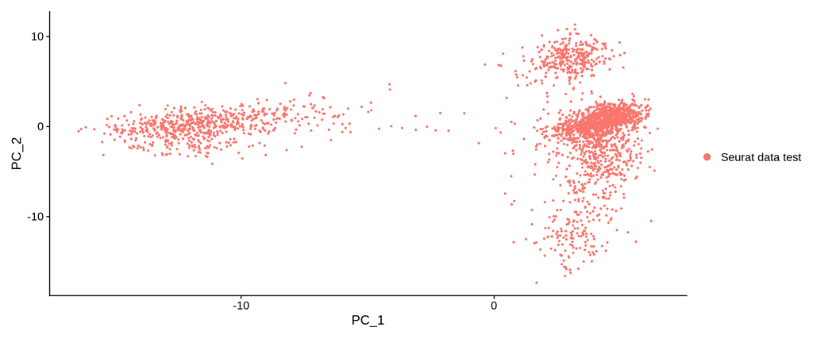

```r
pbmc_small <- RunPCA(pbmc_small,                 #SeuratObject
                     reduction.name = "pca",     #name of the reduction stored in the reduction slot
                     npcs = 50,                  #Total Number of PCs to compute and store (50 by default)
                     seed.use = 42,              #Set a random seed. By default, sets the seed to 42.
                     verbose = TRUE)

# Graphic representation of cells
PCAPlot(pbmc_small,                              #SeuratObject
        dims = c(1, 2))                          #dimensions (PCs) to plot, default is the first two
```

Le slot `nomobjet@reductions$pca` est maintenant cree, il est compose de plusieurs sous slots :

- `@cell.embeddings` : dataframe des coordonnes des cellules sur les differentes PCs
- `@feature.loadings` : dataframe des feature loadings (interpretes comme les coefficients de la combinaison lineaire des variables initiales (l’expression des genes) a partir desquelles les PCs sont construites)
- `feature.loadings.projected` : dataframe des feature loadings projetes (vide)
- `@assay.used` : nom de l’assay utilise (ici `"RNA"`)
- `@global` : logique mais pas plus de description trouve sur ce slot
- `@stdev` : vecteur des standard deviation des PCs stockees
- `@key` : prefixe utilise pour nommer les PCs, lie au parametre `reduction.key` de `RunPCA`, defaut `PC_`
- `@jackstraw` : slot prevu pour l’analyse Jack Straw (pour le moment vide)
- `@misc` : decrit comme etant un slot pour des informations annexes supplementaires (vide)

La fonction de plot represente donc nos cellules dans l’espace dimensionnel des deux premiers PCs de la PCA. Par defaut la colorisation des cellules se base sur l’`active.ident` et donc pour le moment, la colonne `orig.ident` des metadata.

### Uniform Manifold Approximation and Projection (UMAP)

Nous avons pu reduire les dimensions a 50 mais tout comme les genes, toutes les composantes principales ne contiennent pas forcement de l’information pertinente. Nous allons tout d’abord selectionner les PCs qui vont être utilisees pour le calcul de la UMAP.

#### Selection des PCs

Pour cela nous pouvons nous baser sur deux methodes, Jack Straw et le Elbow Plot.

##### La methode Jack Straw

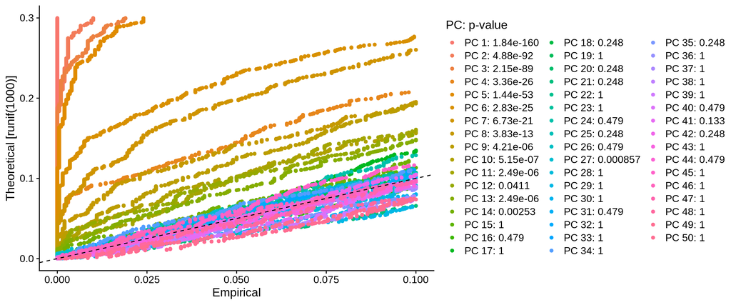

```r
## JackStraw : Determine statistical significance of PCA scores
pbmc_small <- JackStraw(pbmc_small,          #SeuratObject
                        reduction = "pca",   #reduction to analyse
                        dims = 50,           #number of dimension to analyse
                        assay = "RNA")       #assay to use

## Compute Jackstraw scores significance.
pbmc_small <- ScoreJackStraw(pbmc_small,     #SeuratObject
                             dims = 1:50)    #number of dimension to analyse

### Representation JackStrow
JackStrawPlot(pbmc_small,                    #SeuratObject
              dims = 1:50)                   #number of dimension to plot
```

##### La methode de l’Elbow plot

Cette methode consiste a reperer un *“coude”* dans la distribution des standard deviations des differentes PCs.

> Je trouve cette methode beaucoup plus complique pour statuer le nombre de PCs a garder. Mais elle permet d’avoir un second avis, a choisir je me base plus preferentiellement sur le resultat du Jack Straw

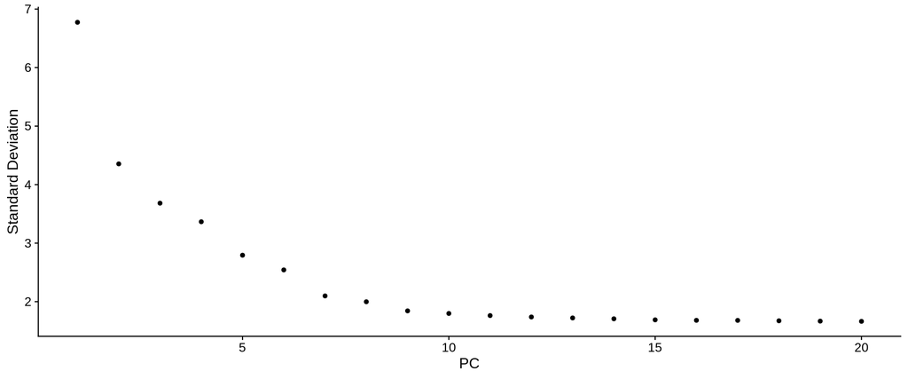

```r
ElbowPlot(pbmc_small,           #SeuratObject
          ndims = 20,           #number of dimension to analyse
          reduction = "pca")    #reduction to analyse
```

Apres visualisation du Elbow plot avec 50 PCs, nous avons reduit a 20PCs car c’etait trop complique pour observer un coude. Ici on pourrait voir un petit saut dans la distribution entre les PCs 10 et 15 ce qui corroborerait avec les resultats du Jack Straw.

–> On peut determiner le choix du nombre de PCs a **10**.

#### Inference de la UMAP

Meme si la PCA permet de reduire les dimensions et de nous permettre d’entrapercevoir des groupes de cellules, la methode de la UMAP permet d’ameliorer ce signal. En effet a partir de la matrice de coordonnees de la PCA, il va construire un graphe qui permet de representer nos cellules dans un espace dimensionnel encore plus restreint tout en gardant au maximum la structure global de notre nuage de point initial.

On utilise d’ailleurs beaucoup plus la UMAP que la t-SNE desormais car cette derniere represente les distances de maniere plus complexes. La structure du nuage de point dans les dimensions d’une t-SNE fait que les distances ne peuvent pas etre reellement considerees comme correles lineairement avec la similarite entre cellules. Grosso modo, les distances de proche en proche entre cellules permet d’affirmer que ces cellules se ressemblent, en revanche les distances entre groupes de cellules ne peuvent pas etre interepreter comme autant different les uns des autres.

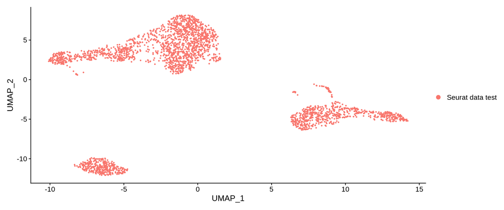

```r
pbmc_small <- RunUMAP(pbmc_small,               #SeuratObject
                      reduction = "pca",        #reduction used to compute UMAP
                      reduction.key = "UMAP_",  #dimension prefix
                      assay = "RNA",            #assay to use
                      dims = 1:10)              #number of PCs to keep (previously determined)

#plot
UMAPPlot(pbmc_small)
```

La fonction de plot represente donc nos cellules dans l’espace dimensionnel des deux premieres dimensions de la UMAP. Par defaut la colorisation des cellules se base sur l’`active.ident` donc la colonne `orig.ident` des metadata.

## Generation des groupes de cellules

Maintenant que nous pouvons observer des groupes de cellules, il nous faut desormais etre capable de les identifier. Pour cela on va utiliser des methodes computationnelles de regroupement de cellules, appeles clustering.

Dans Seurat, on utilisera deux fonctions. `FindNeighbors` permet de construire un graphe des plus proches voisins partages (*Shared Nearest Neighbors*, SNN). Les noeuds representent les cellules et les liens leur proximite dans l’espace dimensionnel de la PCA. Par defaut, cette fonction ne represente que les 20 plus proches voisins. Les liens sont ensuite retires s’il n’y a pas la reciprocite de la proximite.

A partir de ce graph SNN, `FindClusters` va determiner les clusters en identifiant les groupes de cellules les plus interconnectes base sur l’optimisation de la modularite. Cette methode depend de la resolution que l’on choisit. Plus la resolution est faible, moins il y aura de cluster. Il n’y a pas une seule valeur de resolution valable c’est pour cela que l’on va generer le clustering en s’appuyant sur plusieurs valeurs de resolution et determiner *a posteriori* quelle est celle qui represente le mieux nos populations de cellules.

```r
pbmc_small <- FindNeighbors(pbmc_small,          #SeuratObject
                            reduction = "pca",   #reduction to used
                            k.param = 20,
                            dims = 1:10)         #number of PCs to keep (previously determined)

pbmc_small <- FindClusters(pbmc_small,                                        #SeuratObject
                           resolution = seq(from = 0.2, to = 1.2, by = 0.2),  #Compute clustering with several resolutions (from 0.2 to 1.2 : values usually used)
                           verbose = FALSE)
```

`FindNeighbors` construit deux graphes disponibles dans le slot `nomobjet@graphs` ou l’on peut retrouver toutes les informations sur les graphes NN (nearest neighbors) et SNN (shared nearest neighbors).

`FindClusters` ajoute des colonnes dans les metadata avec le prefixe `[nomassay]_[nomgraph]_res.` suivi par les differentes resolutions computes ainsi que la colonne `seurat_clusters` correspondant aux clusters determines lors de la derniere resolution calculee. L’identite des cellules par defaut contenu dans le slot `active.ident` a maintenant change et correspond aussi a l’identite des clusters de la derniere resolution calculee. Chaque colonne va donc associe un numero de cluster pour chaque cellule. Les numeros de clusters sont attribues selon leur taille (ainsi le cluster 0 sera toujours celui qui sera compose du plus de cellule, et ainsi de suite).

```r
knitr::kable(head(pbmc_small@meta.data), "simple") # preview of the cell metadata
```

|  | orig.ident | nCount_RNA | nFeature_RNA | percent_mito | RNA_snn_res.0.2 | RNA_snn_res.0.4 | RNA_snn_res.0.6 | RNA_snn_res.0.8 | RNA_snn_res.1 | RNA_snn_res.1.2 | seurat_clusters |
| --- | --- | --- | --- | --- | --- | --- | --- | --- | --- | --- | --- |
| AAACATACAACCAC-1 | Seurat data test | 2421 | 781 | 3.0152829 | 0 | 0 | 1 | 1 | 10 | 2 | 2 |
| AAACATTGAGCTAC-1 | Seurat data test | 4903 | 1352 | 3.7935958 | 3 | 3 | 3 | 3 | 2 | 1 | 1 |
| AAACATTGATCAGC-1 | Seurat data test | 3149 | 1131 | 0.8891712 | 0 | 1 | 1 | 1 | 1 | 4 | 4 |
| AAACCGTGCTTCCG-1 | Seurat data test | 2639 | 960 | 1.7430845 | 4 | 5 | 5 | 5 | 6 | 8 | 8 |
| AAACCGTGTATGCG-1 | Seurat data test | 981 | 522 | 1.2232416 | 1 | 6 | 6 | 6 | 7 | 9 | 9 |
| AAACGCACTGGTAC-1 | Seurat data test | 2164 | 782 | 1.6635860 | 0 | 1 | 1 | 1 | 1 | 2 | 2 |

#### Quelle resolution choisir ?

Nous avons plusieurs sets de clusters calcules sur la base de differentes resolutions. Il faut maintenant choisir quelle resolution represente le mieux nos populations de cellules. Un outil permet de nous aiguiller dans ce choix, le package `Clustree` qui represente les relations et la distribution des cellules au sein des clusters aux differentes resolutions.

On utilise pour cela la fonction du meme nom `clustree` qui prend en compte les objets seurat, nous avons juste besoin de lui renseigner le prefixe qui permettra de recuperer toutes les colonnes de resolutions dans nos metadata. Il y a plusieurs autres parametres pour changer l’esthetique de la figure mais ici nous allons tout laisse par defaut.

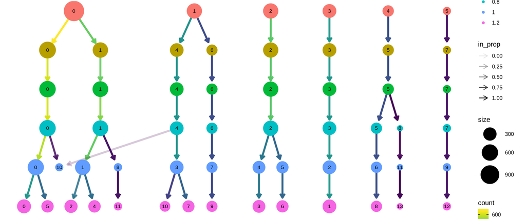

```r
clustree(pbmc_small,               #SeuratObject
         prefix = "RNA_snn_res.")  #Prefix that retrieve all resolution to analyse in cell metadata slot
```

Chaque point correspond a un cluster dont la taille represente le nombre de cellule qui le compose et la couleur, la resolution du clustering. La premiere resolution (en haut) sera toujours la resolution la plus faible, puis on retrace le chemin de chaque cellule au travers des clusters des differentes resolutions (de plus en plus grande) grace aux fleches. On analyse ici 6 resolutions de 0.2 en rouge jusqu’a 1.2 en rose.

Les fleches representent la distribution des clusters d’une resolution plus faible vers les clusters d’une resolution plus elevee. Par exemple, les cellules du cluster 0 de la resolution 0.2 en rouge se repartissent dans les clusters 0 et 1 de la resolution 0.4 en vert kaki. Tandis que le cluster 2 de la resolution 0.2 est compose des memes cellules que le cluster 2 de la resolution 0.4. La couleur des fleches correspond au nombre de cellules du cluster *“parent”* qui alimente le cluster *“enfant”*. L’opacite des fleches represente la proportion de cellules provenant du cluster *“parent”*. C’est sur ce point que clustree nous permet d’identifier la resolution a choisir. Si un cluster a plusieurs origines alors on considere que l’on a trop clusterise les cellules et qu’il faut choisir une resolution plus faible.

On peut observer les faits suivants :

- Les clustering obtenus a partir des resolutions 0.4 et 0.6 sont identiques.
- Tous les clusters ont une seule origine, sauf le cluster 10 de la resolution 1.0.
- Le cluster 10 de la resolution 1.0 est compose majoritairement du cluster 0 de la resolution 0.8 et environ 20% du cluster 4 de la resolution 0.8
- Ce meme cluster 10 ne donne pas de *“descendance”* a la resolution 1.2

Ce dernier fait est inattendu car les cellules du cluster 10 de la resolution 1.0 n’ont pas disparu a la resolution 1.2. Dans quels clusters de la resolution 1.2 se retrouvent les cellules du cluster 10 de la resolution 1.0 ?

```r
table(subset(pbmc_small@meta.data, RNA_snn_res.1 == 10, select = "RNA_snn_res.1.2"))
```

```
##
##  0  1  2  3  4  5  6  7  8  9 10 11 12 13
##  0  0 28  0  0  4  0  0  0  0  0  0  0  0
```

Les cellules du cluster 10 se retrouvent majoritairement dans le cluster 2 puis dans le cluster 5 de la resolution 1.2.

Le choix de la resolution serait 0.8 car apres cela devient plus brouillon. On peut aussi s’aider de la connaissance de notre dataset pour nous orienter sur le nombre de populations de cellules attendu.

On va mettre a jour l’identite par defaut des cellules qui sont accessibles via la fonction `Idents`. Il y a plusieurs maniere de modifier l’identite active en lui renseignant soit un vecteur compose des identites des cellules, soit le nom d’une colonne dans nos metadata.

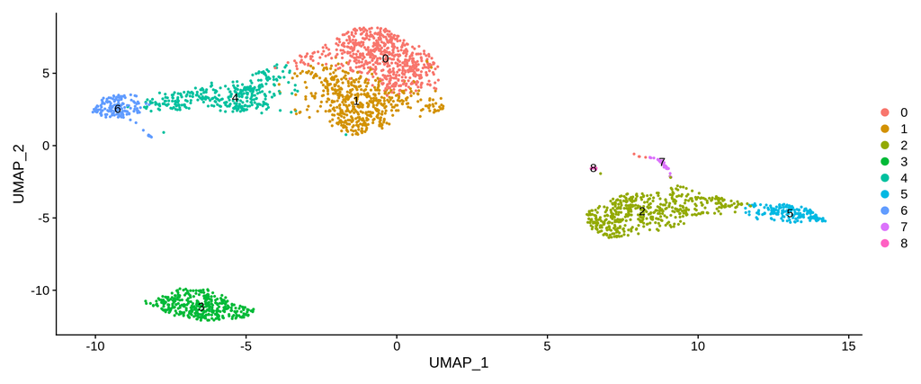

```r
##Set the default resolution level
Idents(pbmc_small) <- "RNA_snn_res.0.8"

##visualize clusters in UMAP coordinates
UMAPPlot(pbmc_small,          #SeuratObject
         label = TRUE,        #Plot label on the plot
         label.size = 4)      #Change label size
```

## Identification et analyses des marqueurs

Nous avons maintenant regroupe nos cellules selon leur profil transcriptomique, il va falloir desormais les identifier. Si on a une connaissance assez pousse de notre dataset, on peut visualiser l’expression des genes specifiques des populations attendues sur la UMAP par exemple ou en Violin Plot afin de determiner quel cluster va les exprimer le plus. Il est aussi possible d’identifier les marqueurs specifiques de chaque cluster en utilisant differents tests d’expression differentielle.

### Identification des marqueurs

#### Identification graphique

Par exemple la litterature nous indique que le gene *MS4A1* (associe a l’ensembl gene ID *ENSG00000156738*) est specifique des cellules B donc en regardant l’expression de ce gene sur la UMAP ou sa distribution en fonction des clusters grace au `VlnPlot` on serait en mesure de determiner quel cluster regrouperait les cellules B.

Pour cela on va tout d’abord utiliser la fonction `FeaturePlot` qui permet de visualiser nos cellules sur un espace dimensionnel reduit (PCA, UMAP,…) une variable continue, cela peut etre l’expression d’un gene ou bien une variable continue des metadata. Puis ensuite nous utiliserons `VlnPlot` qui permet de visualiser une distribution, par defaut il va representer une distribution par identite de cellules contenue dans `active.ident` (on peut utiliser le parametre `group.by` pour utiliser une autre variable).

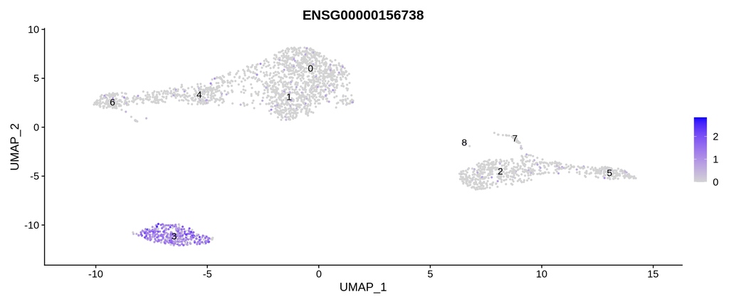

```r
FeaturePlot(pbmc_small,                     #SeuratObject
            features = "ENSG00000156738",   #Value to plot, can be a vector of several variable
            reduction = "umap",             #Dimensional reduction to use
            label = TRUE,                   #Plot label on the plot
            label.size = 4)                 #Change label size
```

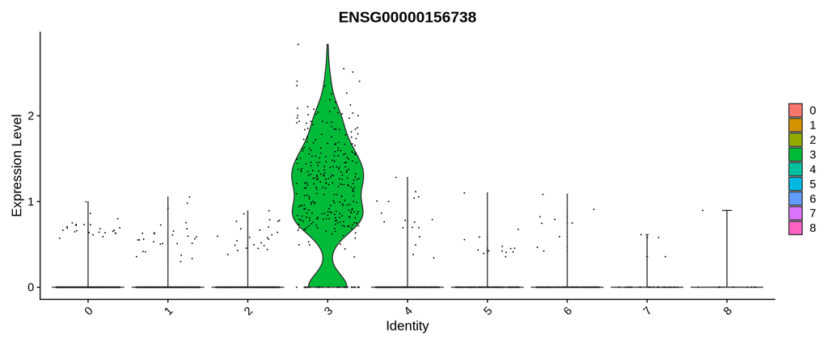

```r
VlnPlot(pbmc_small,                         #SeuratObject
        features = "ENSG00000156738")       #Variable to plot
```

Avec ces resultats on peut considerer le cluster 3 comme etant compose de cellules B.

#### Analyse differentielle d’expression

Il est cependant parfois difficile d’utiliser cette methode pour chacun de nos clusters. Seurat nous propose d’identifier les marqueurs specifique de chaque cluster grace a une methode d’analyse differentielle d’expression.

Pour chaque cluster et chaque gene, la fonction `FindAllMarkers` va determiner s’il y a une difference significative entre l’expression du gene des cellules de notre cluster et les autres cellules. Par defaut, il utilise le test non parametrique de Wilcoxon Rank Sum (ou appele Mann-Whitney).

```r
pbmc_markers <- FindAllMarkers(pbmc_small,              #SeuratObject
                               only.pos = FALSE,        #Returns positive and negative gene markers
                               min.pct = 0.1,           #Take into account genes that are detected in at least 10% of the cells
                               logfc.threshold = 0.25,  #Return markers with a logFC superior to threshold
                               test.use = "wilcox",     #Method used
                               verbose = FALSE)

#Preview of the resulting dataframe
knitr::kable(head(pbmc_markers), "simple")
```

|  | p_val | avg_log2FC | pct.1 | pct.2 | p_val_adj | cluster | gene |
| --- | --- | --- | --- | --- | --- | --- | --- |
| ENSG00000137154 | 0 | 0.6526858 | 0.998 | 0.997 | 0 | 0 | ENSG00000137154 |
| ENSG00000112306 | 0 | 0.6912552 | 1.000 | 0.994 | 0 | 0 | ENSG00000112306 |
| ENSG00000144713 | 0 | 0.6027208 | 0.998 | 0.997 | 0 | 0 | ENSG00000144713 |
| ENSG00000177954 | 0 | 0.6899934 | 0.998 | 0.995 | 0 | 0 | ENSG00000177954 |
| ENSG00000164587 | 0 | 0.5825527 | 1.000 | 0.997 | 0 | 0 | ENSG00000164587 |
| ENSG00000118181 | 0 | 0.7042204 | 1.000 | 0.979 | 0 | 0 | ENSG00000118181 |

Le resultat de cette fonction est un dataframe avec plusieurs colonnes :

- `p_val` : p-valeur du test utilise
- `avg_log2FC` : log2(Fold change +1) entre la moyenne d’expression du cluster considere et la moyenne d’expression du reste des cellules
- `pct.1` : pourcentage de detection du gene au sein de notre cluster
- `pct.2`: pourcentage de detectection du gene au sein du reste des cellules
- `p_val_adj` : p-valeur ajustee
- `cluster` : cluster considere
- `gene` : nom du gene

> Attention ne pas prendre en compte le noms des lignes dans ce dataframe. En effet, il est assez frequent qu’un gene soit defini comme marqueur pour plusieurs cluster ce qui va dupliquer les noms de lignes et donc rajouter des suffixes dans les rownames.

```r
pbmc_markers <- subset(pbmc_markers, p_val_adj < 0.05) #filter dataframe based on p_val_adj column

table(pbmc_markers$cluster)
```

```
##
##   0   1   2   3   4   5   6   7   8
## 324 192 512 336 182 436 392 129 262
```

### Annotation des marqueurs

#### Via Biomart

#### Via ClusterProfiler

## Visualisations